# Session 12

Financing data governance

[Ernest Guevarra](https://ernest.guevarra.io)

ernest@guevarra.io

[University of Oxford](https://www.tropicalmedicine.ox.ac.uk/study-with-us/msc-ihtm)

## Costs of data governance

## Technology infrastructure costs

- Data governance platforms: $50,000-$500,000+ annually
- Metadata management tools: $40,000-$300,000 annually
- Data quality and profiling tools: $30,000-$250,000 annually
- Data catalog solutions: $50,000-$400,000 annually

## Human resource expenses

- Chief Data Officer salary: $175,000-$350,000+
- Data governance managers: $120,000-$180,000
- Data stewards: $85,000-$130,000 per resource
- Compliance specialists: $90,000-$150,000

## Implementation and consulting fees

- Initial implementation consulting: $100,000-$500,000+
- Strategy development: $50,000-$200,000
- Program design: $75,000-$250,000
- Training and change management: $30,000-$150,000

## Compliance-driven governance requirements

- Sector/industry-specific: healthcare regulations compliance; financial services compliance
- General compliance requirements
  - for example, GDPR compliance costs average $1.4 million for mid-sized enterprises
  - Ongoing maintenance and updates add 30-40% annually to initial costs

## Optimising data governance investment

## Phased Implementation

- Prioritise governance capabilities based on risk and compliance requirements
- Start with high-risk data domains and expand systematically.

## Cloud-Based Solutions

- Cloud-based data governance platforms often provide lower initial costs and more predictable pricing models than on-premises alternatives.
- Organisations can reduce total cost of ownership by 30-45% over five years through cloud-based governance solutions.

## Integrated Governance Frameworks

- Develop a unified approach addressing multiple compliance requirements simultaneously rather than creating siloed compliance programs.
- This can reduce duplicative controls by 25-40%.

## Automation and AI

- Emerging AI-driven governance tools can reduce manual effort for data classification, monitoring, and remediation.
- Automation can lower ongoing governance costs by 20-35%.

## Funding data governance

## Use data to improve free cash flow

- Where does data cause cash flow pain?
- Manual vs automated systems for repeated processes
- Show how improved governance can increase efficiency

## Increase revenues with data

- Assess value of your data and leverage this value
- Increase customer satisfaction with data

[figure not shown]

## Cutting costs with data

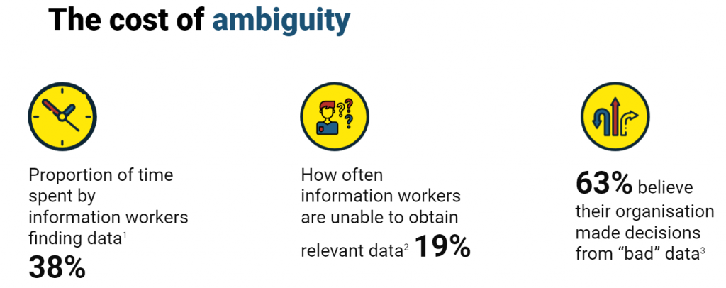

- About 530,000 days of managers’ time wasted by poor quality and undocumented data (equivalent to some $250 million in wages annually)
- By just simply documenting your metadata can reduce data-related expenses by up to 97%

## Reducing risk with data

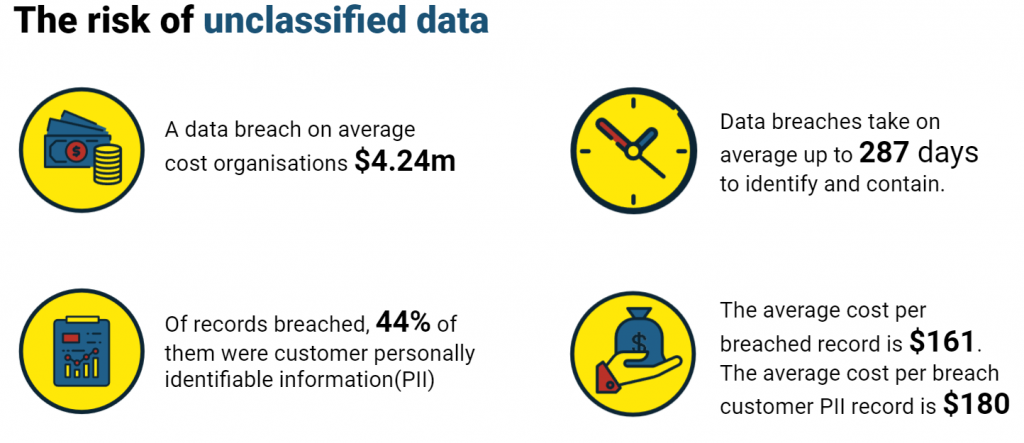

- Regulatory risk (GDPR fines, for example)
- Cybersecurity risk (both costs of the response and erosion of customer trust)

## Generating financial resources for data

- Use data valuations to pinpoint parts of the business where data can increase revenue, unlock cash flow, or reduce costs and risk.
- This gives you a concrete basis for discussions with leadership about investing in data improvements.
- Instead of requesting budget without evidence, you approach the CFO with solid, data-driven justification.
- Securing funding for data governance becomes much easier when the financial benefits are clearly understood.